# RITHEESH-STDS Assignment 2

```python
import numpy as np
import pandas as pd
import seaborn as sns
import matplotlib.pyplot as plt
import scipy.stats as st
import statsmodels.stats as stm
```

Q1 (Binomial Distribution) After demonetisation customers stand in the queue at ATM’s to get new currencies. It was found that the probability of getting a new currency of Rs.2000 by a customer is 0.67. In a randomly selected 5 customers what is the probability that (a) None got new Rs.2000 currency (b) Between 2 to 4 got new Rs.2000 currency (c) More than 4 got new Rs.2000 currency

```python
n=5
p=0.67
q=1-p
```

```python
#(a) None got new Rs.2000 currency
x1=0
print("The probability of none getting the new Rs.2000 currency is",round(st.binom.pmf(x1,n,p)*100,2))
```

```
The probability of none getting the new Rs.2000 currency is 0.39
```

```python
#(b) Between 2 to 4 got new Rs.2000 currency
print("The probability of getting new Rs.2000 between 2 to 4 customers are",round((st.binom.cdf(4,n,p)-st.binom.cdf(2,n,p))*100,2))
```

```
The probability of getting new Rs.2000 between 2 to 4 customers are 66.0
```

```python
#(c) More than 4 got new Rs.2000 currency
print("The probability of getting new Rs.2000 more than 4 customers are",round(st.binom.sf(4,n,p)*100,2))
```

```
The probability of getting new Rs.2000 more than 4 customers are 13.5
```

Q2 (Normal Distribution) The sick-leave time of employees in a firm in a month is normally distributed with mean of 100 hours and a variance of 400 hours. (a) What is the probability that all the sick-leave time for next time will lie between 50 and 80 hours? (b) What is the probability that all the sick-leave time for next time will be 100 hours?

```python
mu=100
sigma=np.sqrt(400)
```

```python
#(a) What is the probability that all the sick-leave time for next time will lie between 50 and 80 hours?
print(round((st.norm.cdf(80,mu,sigma)-st.norm.cdf(50,mu,sigma))*100,2),"% of employees will have sick-leave time betwee 50 to 80 hours next time")
```

```
15.24 % of employees will have sick-leave time betwee 50 to 80 hours next time
```

```python
# (b) What is the probability that all the sick-leave time for next time will be 100 hours?
print(round(st.norm.pdf(100,mu,sigma)*100,2),"% of employees will have sick-leave time of 100 hours next time")
```

```
1.99 % of employees will have sick-leave time of 100 hours next time
```

Q3 (Poisson Distribution) Twenty sheets of aluminium alloy were examined for surface flaws. The frequency of the number of sheets with a given number of flaws per sheet was as follows: No. of flaws 0 1 2 3 4 5 6 Frequency 4 3 5 2 4 1 1 What is the probability of finding a sheet chosen at random which contains 3 or more surface flaws?

```python
lamda=2.3
x=3
print(round(st.poisson.sf(x-1,lamda)*100,2),"% of sheets choosen at random will have 3 or more surface flaws")
```

```
40.4 % of sheets choosen at random will have 3 or more surface flaws
```

Q4 (poisson distribution) A life insurance salesman sells on the average 3 life insurance policies per week. Use Poisson's law to calculate the probability that in a given week he will sell (a) Some policies (b) 2 or more policies but less than 5 policies. (c) Assuming that there are 5 working days per week, what is the probability that in a given day he will sell one policy?

```python
lamda1=3
```

```python
#(a) Some policies
x=1
print("There is ",round(st.poisson.sf(x-1,lamda1)*100,2),"% chance for a insurance sales man to sell some policies in a week")
```

```
There is  95.02 % chance for a insurance sales man to sell some policies in a week
```

```python
#(b) 2 or more policies but less than 5 policies.
print("The chance of selling 2 or more but less than 5 policies by a salesman is",round((st.poisson.cdf(4,lamda1)-st.poisson.cdf(1,lamda1))*100,2),"%")
```

```
The chance of selling 2 or more but less than 5 policies by a salesman is 61.61 %
```

```python
#(c) Assuming that there are 5 working days per week, what is the probability that in a given day he will sell one policy?
lamda2=3/5
print("In 5 working days a week the chance of selling a policy is",round(st.poisson.pmf(1,lamda2)*100,2),"%")
```

```
In 5 working days a week the chance of selling a policy is 32.93 %
```

Q5 Police records show that number of accident victims died in road traffic accidents is 75%. What is the probability that among 6 randomly selected accident victims 4 will survivor?

```python
p=0.75
n=6
lamda=n*p
print(round(st.poisson.pmf(4,lamda)*100,2),"% of accident victims will be the surviviors among 6 randomly selected accident victims")
```

```
18.98 % of accident victims will be the surviviors among 6 randomly selected accident victims
```

Q6 A nationalized bank sanctions personal loan for its customers. If the probability of sanctioning loan by the bank is 0.67. If 6 persons are selected at random what is the probability that (a) None were sanctioned loan? (b) Between 1 to 4 were sanctioned the loan? (c) More than 4 were sanctioned the loan?

```python
n=6
p=0.67
```

```python
#(a) None were sanctioned loan?
print("There is",round(st.binom.pmf(0,n,p)*100,2),"% of chance that none were sanctioned loan")
```

```
There is 0.13 % of chance that none were sanctioned loan
```

```python
#(b) Between 1 to 4 were sanctioned the loan?
print("There is",round((st.binom.cdf(4,n,p)-st.binom.cdf(1,n,p))*100,2),"% of chance that between 1 to 4 customers will be sanctioned with loan")
```

```
There is 62.52 % of chance that between 1 to 4 customers will be sanctioned with loan
```

```python
#(c) More than 4 were sanctioned the loan?
print("There is",round(st.binom.pmf(4,n,p)*100,2),"% of chance that more than 4 customers will be sanctioned with loan")
```

[output not shown]

Q7 Create population data (100000 observations ) with any distribution, and draw randomly 100 samples with different sample sizes ( 30, 50,100, 500). Find the means of those samples and visualise its distribution and find its mean and standard deviation. What are your inferences from the above tasks?

```python
population1= st.norm.rvs(200, 10, 100000)
```

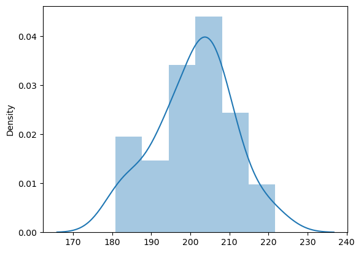

```python
import random
sample1=np.array([np.array(random.sample(list(population1),k=30))])
sample1
sns.distplot(sample1)
```

```python
sample1.mean()
```

```
200.95782148703566
```

```python
sample1.std()
```

```
9.683059793388116
```

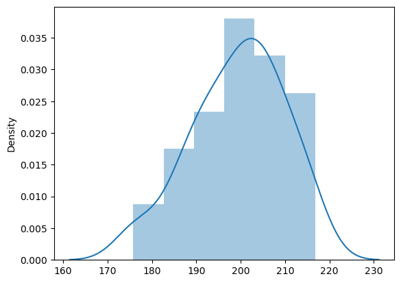

```python
sample2=np.array([np.array(random.sample(list(population1),k=50))])
sample2
sns.distplot(sample2)
```

```python
sample2.mean()
```

```
199.37265452080123
```

```python
sample2.std()
```

```
10.305647253520206
```

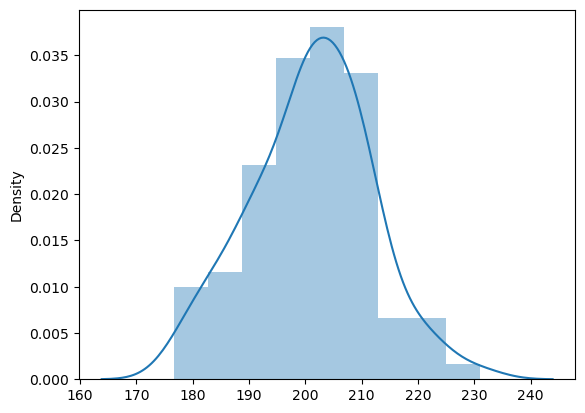

```python
sample3=np.array([np.array(random.sample(list(population1),k=100))])
sample3
sns.distplot(sample3)
```

```python
sample3.mean()
```

```
201.05336801979138
```

```python
sample3.std()
```

```
10.697163761883637
```

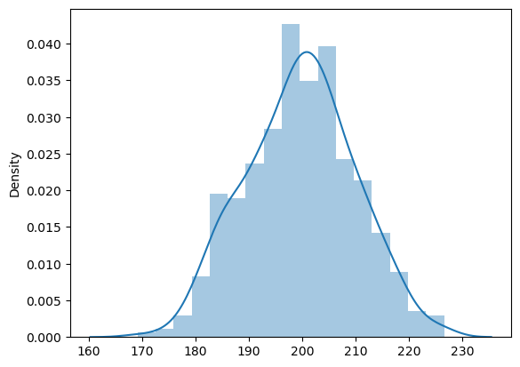

```python
sample4=np.array([np.array(random.sample(list(population1),k=500))])
sample4
sns.distplot(sample4)
```

```python
sample4.mean()
```

```
199.635511638145
```

```python
sample4.std()
```

```
10.178597564039242
```

#Inference I have creates a sample using normal distribution and fron the task i observe that if we increase the sample size the curve almost follows normal distributionQ8 Compact Innovation Avenues Private Limited is the leading manufacturer of stationary items , established in 2018 in Bangalore. Pencils manufactured by this company is expected to have a mean length of 172 mm and the standard deviation of the length is 0.02 mm. To ensure the quality, a sample is selected at periodic intervals to determine whether the length is still 172 mm to meet the quality standards set by the company. You select a random sample of 100 pencils follows a normal distribution and the mean is 170 mm.** a) Construct a 99% confidence interval for the pencil length. b) Construct a 95% confidence interval for the pencil length. c) state your inferences on the above results of a and b

```python
sample=st.norm.rvs(172,0.02,100)
print(len(sample))
```

```
100
```

```python
#Step2:
alpha=0.01
```

```python
#step3:
#population standard deviation is known so we use z test
#z_statistic=(xbar-mu)/(sigma/sqrt(n))
mu=172
xbar=np.mean(sample)
sigma=0.02
n=len(sample)
std_error=sigma/np.sqrt(n)
z_stat=(xbar-mu)/std_error
print(z_stat)
```

```
0.0925738461887704
```

```python
#step4: finding the critical value
z_cri=st.norm.isf(alpha/2)
z_cri
```

```
2.575829303548901
```

```python
#step 5:
if abs(z_stat)<abs(z_cri):
    print("The mean length of the pencil is = 172mm")
else:
    print("The mean lengtth of the pencil is != 172mm")
```

```
The mean length of the pencil is = 172mm
```

```python
#Step2:
alpha1=0.05
```

```python
#step3:
#population standard deviation is known so we use z test
#z_statistic=(xbar-mu)/(sigma/sqrt(n))
mu=172
xbar=np.mean(sample)
sigma=0.02
n=len(sample)
std_error=sigma/np.sqrt(n)
z_stat=(xbar-mu)/std_error
print(z_stat)
```

```
0.0925738461887704
```

```python
#step4: finding the critical value
z_cri1=st.norm.isf(alpha1/2)
z_cri1
```

```
1.9599639845400545
```

```python
#step 5:
if abs(z_stat)<abs(z_cri1):
    print("The mean length of the pencil is = 172mm")
else:
    print("The mean lengtth of the pencil is != 172mm")
```

```
The mean length of the pencil is = 172mm
```